# Data Analysis for Study 4

|  | contrast | graph_condition | estimate | SE | df | asymp.LCL | asymp.UCL |
| --- | --- | --- | --- | --- | --- | --- | --- |
| 1 | 1 - 2 | control | 0.1595601 | 0.03277837 | Inf | 0.09531566 | 0.2238045 |
| 2 | 1 - 2 | truncated | 0.2429310 | 0.03277837 | Inf | 0.17868657 | 0.3071754 |

```
##  contrast                            estimate     SE  df z.ratio p.value
##  (1 - 2 control) - (1 - 2 truncated)  -0.0834 0.0464 Inf -1.798  0.0721
##
## Results are averaged over the levels of: subject_condition
## Degrees-of-freedom method: asymptotic
```

|  | contrast | estimate | SE | df | asymp.LCL | asymp.UCL |
| --- | --- | --- | --- | --- | --- | --- |
| 1 | (1 - 2 control) - (1 - 2 truncated) | -0.08337091 | 0.04635612 | Inf | -0.1742272 | 0.007485417 |

```
## $emmeans
## subject_condition = no warning:
##  session emmean    SE  df asymp.LCL asymp.UCL
##  1         4.34 0.163 Inf      4.02      4.66
##  2         4.18 0.163 Inf      3.86      4.50
##
## subject_condition = warning:
##  session emmean    SE  df asymp.LCL asymp.UCL
##  1         4.23 0.164 Inf      3.91      4.55
##  2         3.99 0.164 Inf      3.66      4.31
##
## Results are averaged over the levels of: graph_condition
## Degrees-of-freedom method: asymptotic
## Confidence level used: 0.95
##
## $contrasts
## subject_condition = no warning:
##  contrast estimate     SE  df z.ratio p.value
##  1 - 2       0.156 0.0327 Inf 4.765   <.0001
##
## subject_condition = warning:
##  contrast estimate     SE  df z.ratio p.value
##  1 - 2       0.247 0.0329 Inf 7.505   <.0001
##
## Results are averaged over the levels of: graph_condition
## Degrees-of-freedom method: asymptotic
```

```
## $emmeans
## subject_condition = no warning:
##  session emmean    SE  df asymp.LCL asymp.UCL
##  1         4.34 0.163 Inf      4.02      4.66
##  2         4.18 0.163 Inf      3.86      4.50
##
## subject_condition = warning:
##  session emmean    SE  df asymp.LCL asymp.UCL
##  1         4.23 0.164 Inf      3.91      4.55
##  2         3.99 0.164 Inf      3.66      4.31
##
## Results are averaged over the levels of: graph_condition
## Degrees-of-freedom method: asymptotic
## Confidence level used: 0.95
##
## $contrasts
## subject_condition = no warning:
##  contrast estimate     SE  df asymp.LCL asymp.UCL
##  1 - 2       0.156 0.0327 Inf    0.0917     0.220
##
## subject_condition = warning:
##  contrast estimate     SE  df asymp.LCL asymp.UCL
##  1 - 2       0.247 0.0329 Inf    0.1823     0.311
##
## Results are averaged over the levels of: graph_condition
## Degrees-of-freedom method: asymptotic
## Confidence level used: 0.95
```

```
##  contrast                                            estimate     SE  df
##  (no warning - warning 1) - (no warning - warning 2)  -0.0911 0.0464 Inf
##  z.ratio p.value
##  -1.965  0.0494
##
## Results are averaged over the levels of: graph_condition
## Degrees-of-freedom method: asymptotic
```

|  | contrast | estimate | SE | df | asymp.LCL | asymp.UCL |
| --- | --- | --- | --- | --- | --- | --- |
| 1 | (no warning - warning 1) - (no warning - warning 2) | -0.09109867 | 0.0463551 | Inf | -0.181953 | -0.0002443388 |

```
## $emmeans
## subject_condition = no warning:
##  graph_condition emmean    SE  df asymp.LCL asymp.UCL
##  control           3.72 0.163 Inf      3.40      4.04
##  truncated         4.80 0.163 Inf      4.48      5.12
##
## subject_condition = warning:
##  graph_condition emmean    SE  df asymp.LCL asymp.UCL
##  control           3.83 0.164 Inf      3.51      4.15
##  truncated         4.38 0.164 Inf      4.06      4.71
##
## Results are averaged over the levels of: session
## Degrees-of-freedom method: asymptotic
## Confidence level used: 0.95
##
## $contrasts
## subject_condition = no warning:
##  contrast            estimate     SE  df z.ratio p.value
##  control - truncated   -1.080 0.0327 Inf -33.061 <.0001
##
## subject_condition = warning:
##  contrast            estimate     SE  df z.ratio p.value
##  control - truncated   -0.551 0.0329 Inf -16.765 <.0001
##
## Results are averaged over the levels of: session
## Degrees-of-freedom method: asymptotic
```

```
## $emmeans
## subject_condition = no warning:
##  graph_condition emmean    SE  df asymp.LCL asymp.UCL
##  control           3.72 0.163 Inf      3.40      4.04
##  truncated         4.80 0.163 Inf      4.48      5.12
##
## subject_condition = warning:
##  graph_condition emmean    SE  df asymp.LCL asymp.UCL
##  control           3.83 0.164 Inf      3.51      4.15
##  truncated         4.38 0.164 Inf      4.06      4.71
##
## Results are averaged over the levels of: session
## Degrees-of-freedom method: asymptotic
## Confidence level used: 0.95
##
## $contrasts
## subject_condition = no warning:
##  contrast            estimate     SE  df asymp.LCL asymp.UCL
##  control - truncated   -1.080 0.0327 Inf    -1.144    -1.016
##
## subject_condition = warning:
##  contrast            estimate     SE  df asymp.LCL asymp.UCL
##  control - truncated   -0.551 0.0329 Inf    -0.616    -0.487
##
## Results are averaged over the levels of: session
## Degrees-of-freedom method: asymptotic
## Confidence level used: 0.95
```

```
## $emmeans
## graph_condition = control:
##  subject_condition emmean    SE  df asymp.LCL asymp.UCL
##  no warning          3.72 0.163 Inf      3.40      4.04
##  warning             3.83 0.164 Inf      3.51      4.15
##
## graph_condition = truncated:
##  subject_condition emmean    SE  df asymp.LCL asymp.UCL
##  no warning          4.80 0.163 Inf      4.48      5.12
##  warning             4.38 0.164 Inf      4.06      4.71
##
## Results are averaged over the levels of: session
## Degrees-of-freedom method: asymptotic
## Confidence level used: 0.95
##
## $contrasts
## graph_condition = control:
##  contrast             estimate    SE  df z.ratio p.value
##  no warning - warning   -0.115 0.136 Inf -0.844  0.3986
##
## graph_condition = truncated:
##  contrast             estimate    SE  df z.ratio p.value
##  no warning - warning    0.414 0.136 Inf  3.051  0.0023
##
## Results are averaged over the levels of: session
## Degrees-of-freedom method: asymptotic
```

```
## $emmeans
## graph_condition = control:
##  subject_condition emmean    SE  df asymp.LCL asymp.UCL
##  no warning          3.72 0.163 Inf      3.40      4.04
##  warning             3.83 0.164 Inf      3.51      4.15
##
## graph_condition = truncated:
##  subject_condition emmean    SE  df asymp.LCL asymp.UCL
##  no warning          4.80 0.163 Inf      4.48      5.12
##  warning             4.38 0.164 Inf      4.06      4.71
##
## Results are averaged over the levels of: session
## Degrees-of-freedom method: asymptotic
## Confidence level used: 0.95
##
## $contrasts
## graph_condition = control:
##  contrast             estimate    SE  df asymp.LCL asymp.UCL
##  no warning - warning   -0.115 0.136 Inf    -0.381     0.152
##
## graph_condition = truncated:
##  contrast             estimate    SE  df asymp.LCL asymp.UCL
##  no warning - warning    0.414 0.136 Inf     0.148     0.681
##
## Results are averaged over the levels of: session
## Degrees-of-freedom method: asymptotic
## Confidence level used: 0.95
```

|  | contrast | estimate | SE | df | asymp.LCL | asymp.UCL |
| --- | --- | --- | --- | --- | --- | --- |
| 1 | (no warning - warning control) - (no warning - warning truncated) | -0.5291229 | 0.0463588 | Inf | -0.6199844 | -0.4382613 |

# Supplemental Information

## Methods

### Participants

156 participants reported English as their first language, and 156 reported NA as their first language.

| dem_ed | n | percentage |
| --- | --- | --- |
| 2 | 16 | 10.1910828 |
| 3 | 24 | 15.2866242 |
| 4 | 1 | 0.6369427 |
| 5 | 19 | 12.1019108 |
| 6 | 81 | 51.5923567 |
| 7 | 5 | 3.1847134 |
| 8 | 11 | 7.0063694 |

74% of participants reported having at least a Bachelorâs degree.

| mean_duration | sd_duration | median_duration | min_duration | max_duration | range_duration |
| --- | --- | --- | --- | --- | --- |
| 18.30764 | 23.6759 | 11.66667 | 1.55 | 153.2167 | 151.6667 |

| mean_duration | sd_duration | median_duration | min_duration | max_duration | range_duration |
| --- | --- | --- | --- | --- | --- |
| 18.81868 | 21.24137 | 13.98333 | 1.833333 | 231.2833 | 229.45 |

Session 1 of the experiment took participants an average of M<sub>duration</sub> = 18.31 minutes, (SD<sub>duration</sub> = 23.68 minutes).

Session 2 of the experiment took participants an average of M<sub>duration</sub> = 18.82 minutes, (SD<sub>duration</sub> = 21.24 minutes).

## Results

## Clarifying Timepoint Interactions

### Marginal Means

To clarify the effects of timepoint on people’s ratings with graphs, we estimated marginal means (EMMs) for contrasts of interest (Table S3).

```r
#model
model_full <- lmer(rating ~ subject_condition * graph_condition * session + (1 | participantid), models_df)

# estimated marginal means pair-wise comparisons for all combinations of IVs
emm1 = emmeans(model_full, specs = pairwise ~ graph_condition + session + subject_condition, lmer.df = "satterthwaite")

# estimated marginal means along with the SEs and CIs
# Table S3
  emm1$emmeans
```

```
##  graph_condition session subject_condition emmean    SE  df asymp.LCL
##  control         1       no warning          3.76 0.100 Inf      3.56
##  truncated       1       no warning          4.91 0.100 Inf      4.72
##  control         2       no warning          3.68 0.100 Inf      3.48
##  truncated       2       no warning          4.68 0.100 Inf      4.48
##  control         1       warning             3.95 0.101 Inf      3.76
##  truncated       1       warning             4.51 0.101 Inf      4.31
##  control         2       warning             3.71 0.101 Inf      3.51
##  truncated       2       warning             4.26 0.101 Inf      4.06
##  asymp.UCL
##       3.96
##       5.11
##       3.88
##       4.88
##       4.15
##       4.71
##       3.91
##       4.46
##
## Degrees-of-freedom method: asymptotic
## Confidence level used: 0.95
```

```r
  # comparisons -- automatically adjusts for multiple comparisons
  #emm1$contrasts
```

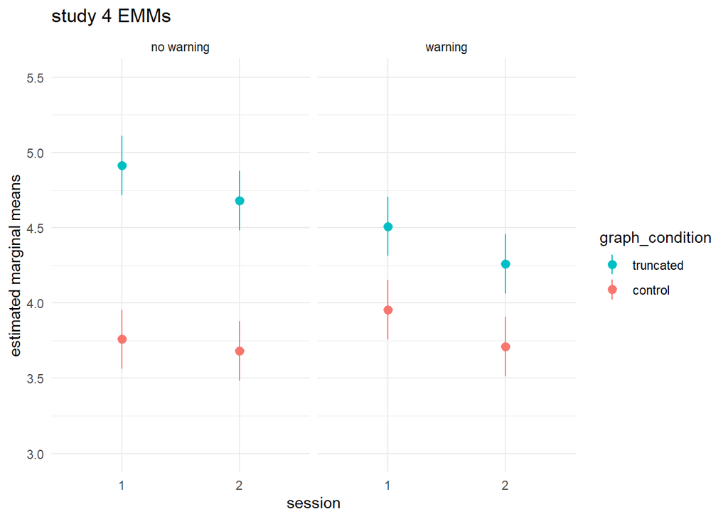

Compare with descriptive means

| graph_condition | session | subject_condition | mean | sd | num | se | lower | upper |
| --- | --- | --- | --- | --- | --- | --- | --- | --- |
| control | 1 | no warning | 3.758861 | 1.692873 | 1580 | 0.04258883 | 3.716272 | 3.801450 |
| control | 1 | warning | 3.954487 | 1.774267 | 1560 | 0.04492175 | 3.909565 | 3.999409 |
| control | 2 | no warning | 3.681013 | 1.718143 | 1580 | 0.04322457 | 3.637788 | 3.724237 |
| control | 2 | warning | 3.711538 | 1.768913 | 1560 | 0.04478619 | 3.666752 | 3.756325 |
| truncated | 1 | no warning | 4.913924 | 1.733384 | 1580 | 0.04360800 | 4.870316 | 4.957532 |
| truncated | 1 | warning | 4.509615 | 1.745122 | 1560 | 0.04418383 | 4.465432 | 4.553799 |
| truncated | 2 | no warning | 4.680380 | 1.745272 | 1580 | 0.04390707 | 4.636473 | 4.724287 |
| truncated | 2 | warning | 4.258974 | 1.778529 | 1560 | 0.04502966 | 4.213945 | 4.304004 |

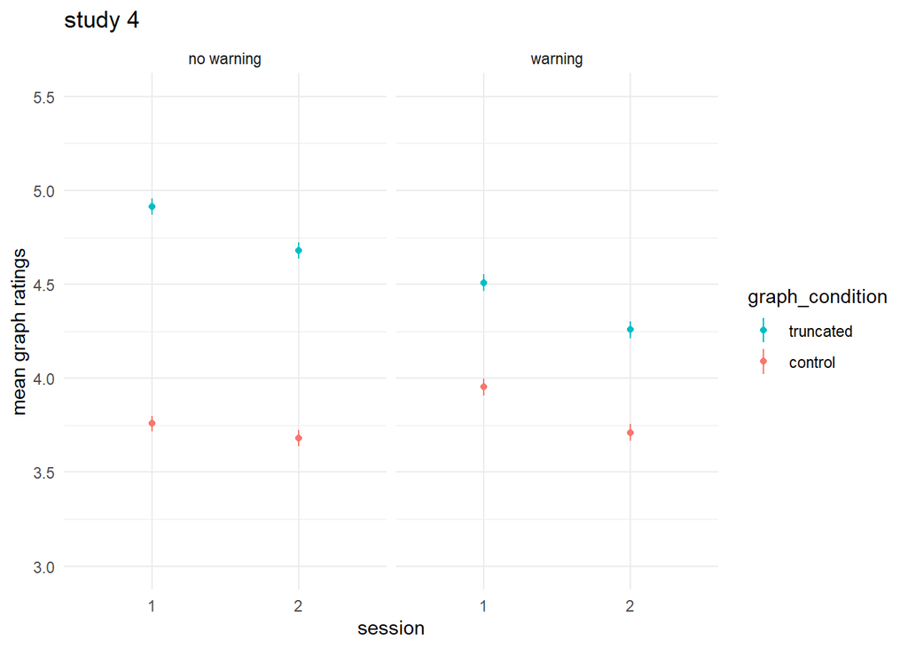